# Spotify Trends - Was macht Songs beliebt?

Autor:innen

Markus Janke,

Tim Beyer

Veröffentlichungsdatum

23. Dezember 2023

# 1 Einleitung (Markus)

# 2 Vorbereitung (Markus, Tim)

Im folgenden Kapitel, werden vorbereitende Maßnahmen getroffen, wie die Installation der benötigten Pakete, das Laden der Pakete und das Einlesen der Daten.

Die benötigten Pakete werden im Hintergrund installiert und geladen, damit diese im weiteren Verlauf verwendet werden können und nicht manuell installiert werden müssen.

```r
dataset <- read_excel("spotify-2023.xlsx")
```

# 3 Überblick über die Daten (Markus, Tim)

Zunächst betrachten wir hier die Dimensionen des Datensatzes um festzustellen, wie viele Zeilen und Spalten enthalten sind.

```r
dim(dataset)
```

```
[1] 953  24
```

```r
describe_tbl(dataset)
```

```
953 observations with 24 variables
137 observations containing missings (NA)
3 variables containing missings (NA)
0 variables with no variance
```

Um einen weiteren Überblick über die Daten zu erhalten, werden die Spalten Namen aufgelistet.

```r
colnames(dataset)
```

```
 [1] "track_name"           "artist(s)_name"       "artist_count"
 [4] "released_year"        "released_month"       "released_day"
 [7] "in_spotify_playlists" "in_spotify_charts"    "streams"
[10] "in_apple_playlists"   "in_apple_charts"      "in_deezer_playlists"
[13] "in_deezer_charts"     "in_shazam_charts"     "bpm"
[16] "key"                  "mode"                 "danceability_%"
[19] "valence_%"            "energy_%"             "acousticness_%"
[22] "instrumentalness_%"   "liveness_%"           "speechiness_%"
```

| Spaltenname | Datentyp | Beschreibung |
| --- | --- | --- |
| track_name | character | Name des Songs |
| artist(s)_name | character | Name(n) der Künstler:innen die an einem Song mitgewirkt haben |
| artist_count | numeric | Anzahl der Künstler:innen die an einem Song mitgewirkt haben |
| released_year | numeric | Jahr der Veröffentlichung |
| released_month | numeric | Monat der Veröffentlichung |
| released_day | numeric | Tag des Monats der Veröffentlichung |
| in_spotify_playlists | numeric | Anzahl der Spotify Playlisten in denen ein Song enthalten ist |
| in_spotify_charts | numeric | Präsenz und Rang in den Spotify Charts |
| streams | numeric | Gesamte Anzahl der Streams auf Spotify |
| in_apple_playlists | numeric | Anzahl der Apple Music Playlisten in denen ein Song enthalten ist |
| in_apple_charts | numeric | Präsenz und Rang in den Apple Music Charts |
| in_deezer_playlists | numeric | Anzahl der Deezer Playlisten in denen ein Song enthalten ist |
| in_deezer_charts | numeric | Präsenz und Rang in den Deezer Charts |
| in_shazam_charts | numeric | Präsenz und Rang in den Shazam Charts |
| bpm | numeric | Beats pro Minute (Eine Einheit für die Geschwindigkeit von Songs) |
| key | character | Tonart des Songs |
| mode | character | Tongeschlecht des Songs |
| danceability_% | numeric | prozentuelle Angabe, die angibt wie gut sich ein Song zum Tanzen eignet |
| valence_% | numeric | Positivität des musikalischen Inhalt des Songs |
| energy_% | numeric | Das wahrgenommene Energielevel eines Songs |
| acousticness_% | numeric | Anteil an akustischem Klang in einem Song |
| instrumentalness_% | numeric | Instrumentalische Anteil eines Songs |
| liveness_% | numeric | Präsenz von Live-Performance Elementen in einem Song |
| speechiness_% | numeric | Anteil an gesprochenen Wörtern in einem Song |

Um abschließend noch ein gesamtes Bild des Datensatzes zu bekommen, werden alle Spalten zusammengefasst.

```r
summary(dataset)
```

```
  track_name        artist(s)_name      artist_count   released_year
 Length:953         Length:953         Min.   :1.000   Min.   :1930
 Class :character   Class :character   1st Qu.:1.000   1st Qu.:2020
 Mode  :character   Mode  :character   Median :1.000   Median :2022
                                       Mean   :1.556   Mean   :2018
                                       3rd Qu.:2.000   3rd Qu.:2022
                                       Max.   :8.000   Max.   :2023

 released_month    released_day   in_spotify_playlists in_spotify_charts
 Min.   : 1.000   Min.   : 1.00   Min.   :   31        Min.   :  0.00
 1st Qu.: 3.000   1st Qu.: 6.00   1st Qu.:  875        1st Qu.:  0.00
 Median : 6.000   Median :13.00   Median : 2224        Median :  3.00
 Mean   : 6.034   Mean   :13.93   Mean   : 5200        Mean   : 12.01
 3rd Qu.: 9.000   3rd Qu.:22.00   3rd Qu.: 5542        3rd Qu.: 16.00
 Max.   :12.000   Max.   :31.00   Max.   :52898        Max.   :147.00

    streams          in_apple_playlists in_apple_charts  in_deezer_playlists
 Min.   :2.762e+03   Min.   :  0.00     Min.   :  0.00   Min.   :  0.0
 1st Qu.:1.416e+08   1st Qu.: 13.00     1st Qu.:  7.00   1st Qu.:  9.0
 Median :2.905e+08   Median : 34.00     Median : 38.00   Median : 31.0
 Mean   :5.141e+08   Mean   : 67.81     Mean   : 51.91   Mean   :100.9
 3rd Qu.:6.739e+08   3rd Qu.: 88.00     3rd Qu.: 87.00   3rd Qu.:100.0
 Max.   :3.704e+09   Max.   :672.00     Max.   :275.00   Max.   :974.0
 NA's   :1
 in_deezer_charts in_shazam_charts      bpm            key
 Min.   : 0.000   Min.   :  0.00   Min.   : 65.0   Length:953
 1st Qu.: 0.000   1st Qu.:  0.00   1st Qu.:100.0   Class :character
 Median : 0.000   Median :  2.00   Median :121.0   Mode  :character
 Mean   : 2.666   Mean   : 50.79   Mean   :122.5
 3rd Qu.: 2.000   3rd Qu.: 35.50   3rd Qu.:140.0
 Max.   :58.000   Max.   :953.00   Max.   :206.0
                  NA's   :50
     mode           danceability_%    valence_%        energy_%
 Length:953         Min.   :23.00   Min.   : 4.00   Min.   : 9.00
 Class :character   1st Qu.:57.00   1st Qu.:32.00   1st Qu.:53.00
 Mode  :character   Median :69.00   Median :51.00   Median :66.00
                    Mean   :66.97   Mean   :51.43   Mean   :64.28
                    3rd Qu.:78.00   3rd Qu.:70.00   3rd Qu.:77.00
                    Max.   :96.00   Max.   :97.00   Max.   :97.00

 acousticness_%  instrumentalness_%   liveness_%    speechiness_%
 Min.   : 0.00   Min.   : 0.000     Min.   : 3.00   Min.   : 2.00
 1st Qu.: 6.00   1st Qu.: 0.000     1st Qu.:10.00   1st Qu.: 4.00
 Median :18.00   Median : 0.000     Median :12.00   Median : 6.00
 Mean   :27.06   Mean   : 1.581     Mean   :18.21   Mean   :10.13
 3rd Qu.:43.00   3rd Qu.: 0.000     3rd Qu.:24.00   3rd Qu.:11.00
 Max.   :97.00   Max.   :91.000     Max.   :97.00   Max.   :64.00
```

In der Zusammenfassung lässt sich schon erkennen, wie weit die Wertebereiche der Spalten aussehen. Außerden lassen sich hier auch schon 50 NAs in der Spalte in_shazam_charts erkennen, sowie ein NA in der Spalte streams. Zu der oben festgestellten Anzahl von NAs besteht hier eine große Diskrepanz, die wir genauer betrachten müssen. Darüber hinaus ist festzustellen, dass die Spalten mit dem Datentyp character nicht in der Zusammenfassung auftauchen. Dies liegt daran, dass diese Spalten nicht numerisch sind. Um diese Spalten dennoch zu betrachten, wird die Funktion skimr verwendet, da diese eine ausführlichere Zusammendassung des Datensatzes bietet.

```r
skimr::skim(dataset)
```

Data summary

| Name | dataset |
| --- | --- |
| Number of rows | 953 |
| Number of columns | 24 |
| _______________________ |  |
| Column type frequency: |  |
| character | 4 |
| numeric | 20 |
| ________________________ |  |
| Group variables | None |

**Variable type: character**

| skim_variable | n_missing | complete_rate | min | max | empty | n_unique | whitespace |
| --- | --- | --- | --- | --- | --- | --- | --- |
| track_name | 0 | 1.0 | 2 | 123 | 0 | 943 | 0 |
| artist(s)_name | 0 | 1.0 | 1 | 117 | 0 | 645 | 0 |
| key | 95 | 0.9 | 1 | 2 | 0 | 11 | 0 |
| mode | 0 | 1.0 | 5 | 5 | 0 | 2 | 0 |

**Variable type: numeric**

| skim_variable | n_missing | complete_rate | mean | sd | p0 | p25 | p50 | p75 | p100 | hist |
| --- | --- | --- | --- | --- | --- | --- | --- | --- | --- | --- |
| artist_count | 0 | 1.00 | 1.56 | 0.89 | 1 | 1 | 1 | 2.0 | 8 | ▇▁▁▁▁ |
| released_year | 0 | 1.00 | 2018.24 | 11.12 | 1930 | 2020 | 2022 | 2022.0 | 2023 | ▁▁▁▁▇ |
| released_month | 0 | 1.00 | 6.03 | 3.57 | 1 | 3 | 6 | 9.0 | 12 | ▇▆▅▃▆ |
| released_day | 0 | 1.00 | 13.93 | 9.20 | 1 | 6 | 13 | 22.0 | 31 | ▇▅▃▆▃ |
| in_spotify_playlists | 0 | 1.00 | 5200.12 | 7897.61 | 31 | 875 | 2224 | 5542.0 | 52898 | ▇▁▁▁▁ |
| in_spotify_charts | 0 | 1.00 | 12.01 | 19.58 | 0 | 0 | 3 | 16.0 | 147 | ▇▁▁▁▁ |
| streams | 1 | 1.00 | 514137424.94 | 566856949.04 | 2762 | 141636175 | 290530915 | 673869022.0 | 3703895074 | ▇▂▁▁▁ |
| in_apple_playlists | 0 | 1.00 | 67.81 | 86.44 | 0 | 13 | 34 | 88.0 | 672 | ▇▁▁▁▁ |
| in_apple_charts | 0 | 1.00 | 51.91 | 50.63 | 0 | 7 | 38 | 87.0 | 275 | ▇▃▂▁▁ |
| in_deezer_playlists | 0 | 1.00 | 100.93 | 173.73 | 0 | 9 | 31 | 100.0 | 974 | ▇▁▁▁▁ |
| in_deezer_charts | 0 | 1.00 | 2.67 | 6.04 | 0 | 0 | 0 | 2.0 | 58 | ▇▁▁▁▁ |
| in_shazam_charts | 50 | 0.95 | 50.79 | 126.07 | 0 | 0 | 2 | 35.5 | 953 | ▇▁▁▁▁ |
| bpm | 0 | 1.00 | 122.54 | 28.06 | 65 | 100 | 121 | 140.0 | 206 | ▃▇▇▃▁ |
| danceability_% | 0 | 1.00 | 66.97 | 14.63 | 23 | 57 | 69 | 78.0 | 96 | ▁▃▆▇▃ |
| valence_% | 0 | 1.00 | 51.43 | 23.48 | 4 | 32 | 51 | 70.0 | 97 | ▅▇▇▇▅ |
| energy_% | 0 | 1.00 | 64.28 | 16.55 | 9 | 53 | 66 | 77.0 | 97 | ▁▂▅▇▃ |
| acousticness_% | 0 | 1.00 | 27.06 | 26.00 | 0 | 6 | 18 | 43.0 | 97 | ▇▃▂▁▁ |
| instrumentalness_% | 0 | 1.00 | 1.58 | 8.41 | 0 | 0 | 0 | 0.0 | 91 | ▇▁▁▁▁ |
| liveness_% | 0 | 1.00 | 18.21 | 13.71 | 3 | 10 | 12 | 24.0 | 97 | ▇▂▁▁▁ |
| speechiness_% | 0 | 1.00 | 10.13 | 9.91 | 2 | 4 | 6 | 11.0 | 64 | ▇▁▁▁▁ |

Die Methode skimr erstellt nun mehrere Ausgaben und nimmt dabei einige der oben schon Betrachtungen mit auf, wie die Anzahl der Zeilen und Spalten. Des Weiteren betrachtet die Methode auch die Spalten mit dem Datentyp character im Detail, wodurch sich feststellen lässt, dass in der Spalte key noch 95 NAs versteckt waren. Insgesamt kommen wir mit den NAs aus streams und in_shazam_charts auf 146 NAs, was von den oben ausgegebenen 137 NAs abweicht. Es wurde versucht festzustelle, woran dieser Unterschied liegen könnte, jedoch konnte keine Erklärung gefunden werden. Nach manuellem Nachzählen gehen wir davon aus, dass die Anzahl der NAs in der Zusammenfassung von skimr korrekt ist und die Anzahl der NAs in der Zusammenfassung von describe_tbl fehlerhaft ist, was aus unterschiedliche Programmierung bei der Erkennung von NAs zurückzuführen sein kann. Die Erkenntnisse in diesem Kapitel bilden damit auch die Grundlage für die Bereinigung der Daten, welche im nächsten Kapitel durchgeführt wird.

# 4 Bereinigung der Daten (Tim)

In der Spalte streams ist ein NA enthalten, da Streams die wichtigste und aussagekräftigste Spalte ist, wird diese Beobachtung gelöscht. Es gibt leider keine Möglichkeit, dass diese Beobachtung so aufbereitet werden kann, dass sie für die weitere Betrachtung relevant ist. Da sowohl das Einsetzen des Mittelwerts als auch das Schätzen des Werts im weiteren Verlauf zu Verfälschungen führen könnten.

```r
dataset <- dataset[!is.na(dataset$streams), ]
```

Neben der Spalte streams hat auch die Spalte in_shazam_charts NAs, in diesem Fall soagr 50. Dies kann darauf zurückzuführen sein, dass die entsprechenden Songs auf Shazam nicht verfügbar sind, da Shazam beispielsweise nicht die Rechte für das Abspielen des Songs hat. Da Shazam insgesamt ein nicht sehr beliebter Musikstreamingsienst ist, wird diese Spalte entfernt, da sie für die weitere Betrachtung nicht relevant ist.

```r
dataset$in_shazam_charts <- NULL
```

```r
dataset$key <- NULL
```

Wie in der Betrachtung der Daten festgestellt, enthalten die Spalten “danceability”, “energy”, “speechiness”, “acousticness”, “instrumentalness”, “liveness”und “valence” enthalten ein “%”. Dies kann zu Problemen bei der weiteren Verarbeitung führen, weshalb diese Spalten umbenannt werden. Um die Aussage der Spaltennamen nicht zu verändern, wir das Prozentzeichen durch das Wort Prozent ersetzt. Die Entscheidung auf des englische Wort für Prozent ist gefallen, da alle restlichen Spaltennamen ebenfalls auf Englisch sind und diese Namenskonvention beibehalten werden soll.

```r
colnames(dataset)[colnames(dataset) == "danceability_%"] <- "danceability_percent"
colnames(dataset)[colnames(dataset) == "energy_%"] <- "energy_percent"
colnames(dataset)[colnames(dataset) == "speechiness_%"] <- "speechiness_percent"
colnames(dataset)[colnames(dataset) == "acousticness_%"] <- "acousticness_percent"
colnames(dataset)[colnames(dataset) == "instrumentalness_%"] <- "instrumentalness_percent"
colnames(dataset)[colnames(dataset) == "liveness_%"] <- "liveness_percent"
colnames(dataset)[colnames(dataset) == "valence_%"] <- "valence_percent"
```

Um eine Übersicht über den bereinigten Datensatz zu bekommen, wird dieser im folgenden noch einmal zusammengefasst. Dies dient vor Allem der Überprüfung, ob alle NAs entfernt wurden und die Spaltennamen korrekt geändert wurden. Außerdem ermöglicht uns die erneute Zusammenfassung hier noch einmal einen Vergleich zum ursprünglichen Datensatz aus dem Kapitel Überblick über die Daten zu ziehen.

```r
skimr::skim(dataset)
```

Data summary

| Name | dataset |
| --- | --- |
| Number of rows | 952 |
| Number of columns | 22 |
| _______________________ |  |
| Column type frequency: |  |
| character | 3 |
| numeric | 19 |
| ________________________ |  |
| Group variables | None |

**Variable type: character**

| skim_variable | n_missing | complete_rate | min | max | empty | n_unique | whitespace |
| --- | --- | --- | --- | --- | --- | --- | --- |
| track_name | 0 | 1 | 2 | 123 | 0 | 942 | 0 |
| artist(s)_name | 0 | 1 | 1 | 117 | 0 | 644 | 0 |
| mode | 0 | 1 | 5 | 5 | 0 | 2 | 0 |

**Variable type: numeric**

| skim_variable | n_missing | complete_rate | mean | sd | p0 | p25 | p50 | p75 | p100 | hist |
| --- | --- | --- | --- | --- | --- | --- | --- | --- | --- | --- |
| artist_count | 0 | 1 | 1.56 | 0.89 | 1 | 1.00 | 1.0 | 2.00000e+00 | 8 | ▇▁▁▁▁ |
| released_year | 0 | 1 | 2018.29 | 11.01 | 1930 | 2020.00 | 2022.0 | 2.02200e+03 | 2023 | ▁▁▁▁▇ |
| released_month | 0 | 1 | 6.04 | 3.56 | 1 | 3.00 | 6.0 | 9.00000e+00 | 12 | ▇▆▅▃▆ |
| released_day | 0 | 1 | 13.94 | 9.20 | 1 | 6.00 | 13.0 | 2.20000e+01 | 31 | ▇▅▃▆▃ |
| in_spotify_playlists | 0 | 1 | 5202.57 | 7901.40 | 31 | 874.50 | 2216.5 | 5.57375e+03 | 52898 | ▇▁▁▁▁ |
| in_spotify_charts | 0 | 1 | 12.02 | 19.58 | 0 | 0.00 | 3.0 | 1.60000e+01 | 147 | ▇▁▁▁▁ |
| streams | 0 | 1 | 514137424.94 | 566856949.04 | 2762 | 141636175.00 | 290530915.0 | 6.73869e+08 | 3703895074 | ▇▂▁▁▁ |
| in_apple_playlists | 0 | 1 | 67.87 | 86.47 | 0 | 13.00 | 34.0 | 8.80000e+01 | 672 | ▇▁▁▁▁ |
| in_apple_charts | 0 | 1 | 51.96 | 50.63 | 0 | 7.00 | 38.5 | 8.70000e+01 | 275 | ▇▃▂▁▁ |
| in_deezer_playlists | 0 | 1 | 100.98 | 173.81 | 0 | 9.00 | 30.5 | 1.00000e+02 | 974 | ▇▁▁▁▁ |
| in_deezer_charts | 0 | 1 | 2.67 | 6.04 | 0 | 0.00 | 0.0 | 2.00000e+00 | 58 | ▇▁▁▁▁ |
| bpm | 0 | 1 | 122.55 | 28.07 | 65 | 99.75 | 121.0 | 1.40250e+02 | 206 | ▅▇▇▃▁ |
| danceability_percent | 0 | 1 | 66.98 | 14.63 | 23 | 57.00 | 69.0 | 7.80000e+01 | 96 | ▁▃▆▇▃ |
| valence_percent | 0 | 1 | 51.41 | 23.48 | 4 | 32.00 | 51.0 | 7.00000e+01 | 97 | ▅▇▇▇▅ |
| energy_percent | 0 | 1 | 64.27 | 16.56 | 9 | 53.00 | 66.0 | 7.70000e+01 | 97 | ▁▂▅▇▃ |
| acousticness_percent | 0 | 1 | 27.08 | 26.00 | 0 | 6.00 | 18.0 | 4.30000e+01 | 97 | ▇▃▂▁▁ |
| instrumentalness_percent | 0 | 1 | 1.58 | 8.41 | 0 | 0.00 | 0.0 | 0.00000e+00 | 91 | ▇▁▁▁▁ |
| liveness_percent | 0 | 1 | 18.21 | 13.72 | 3 | 10.00 | 12.0 | 2.40000e+01 | 97 | ▇▂▁▁▁ |
| speechiness_percent | 0 | 1 | 10.14 | 9.92 | 2 | 4.00 | 6.0 | 1.10000e+01 | 64 | ▇▁▁▁▁ |

In der Zusammenfassung lässt sich direkt erkennen, dass eine Reihe, sowie 2 Spalten entfernt wurden, was den oben vorgenommenen Änderungen entspricht. Außerdem lässt sich erkennen, dass die Anzahl der NAs nun 0 beträgt. Des Weiteren sind die Spaltennamen nun auch korrekt aufgeführt und enthalten keine Sonderzeichen mehr. Damit ist der Datensatz bereinigt und kann für die weitere Betrachtung verwendet werden.

# 5 Berechnung eines Beliebtheitsscores (Tim)

Da für einige der Thesen, sowie der Machine Learning Modelle soll die Beliebtheit eines Songs betrachtet werden. Dies führt zu der Problemstellung, dass mehrere Werte eine Aussage über die Beliebheit eines Songs treffen. Dabei ist es so, dass einige Werte eine Starke aussage auf die Beliebtheit treffen können, andere Werte hingegen treffen nur eine schwächere Aussage. Um ein Beispiel heranzuziehen, die Anzahl der Streams kann eine höhere Aussage über die Beliebtheit treffen, als die Platzierung in den Charts eines Musikstreamingdienstes. Dies leigt daran, dass die Anzahl der Streams eine absolute Größe und eine Aussage trifft wie oft ein Song gehört wird. Die Platzierung und Präsenz in den Charts hingegen ist eine relative Größe, da sie nur die Platzierung im Vergleich zu anderen Songs angibt. Das Ziel ist es, jedoch jetzt eine Kennzahl, also einen Beliebtheitsscore einzuführen, der die verschiedenen Werte zusammenfasst und eine Aussage über die Beliebtheit eines Songs trifft. Der Beliebtheitsscore setzt sich aus den Streams und den Charts der verschiedenen Streamingdienste zusammen. Um den Unterschiedlichen Aussagekräften gerecht zu werden wird für jeden Parameter, der in die Berechnung einfließt eine Gewichtung vorgenommen, die die Aussagekraft des jewiligen Parameters widerspiegelt.

Zudem sollte in Betracht gezogen werden, dass ein Song der vor 2023 oder Anfang des Jahres 2023 veröffentlicht wurde, einen Vorteil gegenüber Songs hat, die später im Jahr 2023 veröffentlicht wurden. Dies liegt daran, dass Songs, die früher veröffentlicht wurden, mehr Zeit hatten, um Streams zu generieren und in den Charts zu erscheinen. Um diesen Vorteil auszugleichen, wird der Beliebtheitsscore durch die Tage geteilt, die der entsprechende Song in diesem Jahr gestreamt werden konnte. Dadurch ergibt sich quasi ein Beliebtheitsscore pro Tag.

Aus den oben genannten Anforderungen an den Beliebtheitsscore ergibt sich folgende Formel:

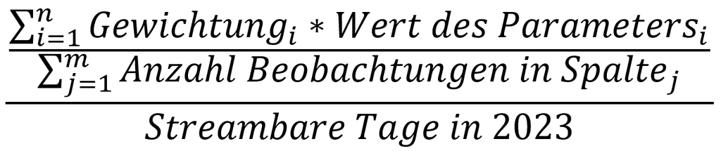

Formel zur Berechnung des Beliebtheitsscores

```r
w_streams <- 1
w_spotify_charts <- 14.29
w_deezer_charts <- 1
w_apple_charts <- 8.57
```

Um die oben beschriebene Vergleichbarkeit zwischen den verschiedenen Beliebtheitsscore je nach Veröffentlichkeitsdatum herzustellen werden zunächt die Tage ermittelt, die ein Song in 2023 streambar war. Dazu werden die Tage berechnet die zwischen der Erstellung des Datensatzes und der Veröffentlichung des Songs liegen. Außerdem werden die Tage berechnet, die zwischen der Veröffentlichung des Songs und dem Beginn dieses Jahres liegen, diese werden besonders im nächsten Schritt benötigt. Anschließend wird sofern der Song vor diesem Jahr veröffentlicht worden ist, die Tage von der Veröffentlichung bis zum Beginn des Jahres (daysFromReleaseToThisYear) von den Tagen seit der Veröffentlichung bis zum Stichtag (daysFromRelease) abgezogen. Dadirch ergibt sich eine maximale Anzahl von 212 Tagen, die ein Song, der vor diesem Jahr veröffentlicht wurde dieses Jahr gestreamt werden konnte, was der Zeit zwischen dem 1.1.2023 und dem 1.8.2023 entspricht. Songs, die am oder nach dem 01.01.2023 veröffentlicht wurden, fließen direkt mit den Tagen seit der Veröffentlichung (daysFromRelease) mit ein.

```r
releaseDate <- paste(dataset$released_day, dataset$released_month, dataset$released_year, sep=".")

daysFromRelease <- round((difftime(strptime("01.08.2023", format = "%d.%m.%Y"),strptime(releaseDate, format = "%d.%m.%Y"))))

daysFromReleaseToThisYear <- round((difftime(strptime("01.01.2023", format = "%d.%m.%Y"),strptime(releaseDate, format = "%d.%m.%Y"))))

streamableDays2023 <- ifelse(daysFromRelease>212, daysFromRelease-daysFromReleaseToThisYear, daysFromRelease)

minStreamableDays <- min(streamableDays2023)
maxStreamableDays <- max(streamableDays2023)
```

Dadurch ergibt sich eine Spanne von *18* bis *212*. Dies zeigt, dass wirklich maximal die Tage, bis zum 01.08.2023 gezählt wurden. Damit haben wir die Anzahl der streambaren Tage in 2023 für jeden Song ermittelt.

Dies führt uns zur entgültigen Berechnung des Beliebtheitsscores. Bei der Berechnung des Beliebtheitssscores wird zunächst der ursprüngliche Wert der einzelnen Spalten mit der entsprechenden Gewichtung multipliziert. Anschließend werden die einzelnen Werte addiert und durch die Summe der Einträge in den Spalten geteilt. Danach wird noch einmal du die oben berechnete Anzahl an streambaren Tagen geteilt um so die Vergleichbarkeit zwischen den Songs zu gewährleisten.

```r
dataset$popularity_score <- (((
  w_streams * dataset$streams +
  w_spotify_charts * dataset$in_spotify_charts +
  w_deezer_charts * dataset$in_deezer_charts +
  w_apple_charts * dataset$in_apple_charts
) / sum(!is.na(dataset[, c("streams", "in_spotify_charts", "in_deezer_charts", "in_apple_charts")]))) / streamableDays2023)
```

Die Berechnung des Beliebtheitsscores ist nun abgeschlossen und es kann mit der weiteren Betrachtung des Datensatzes durch die Thesen fortgefahren werden.

# 6 Thesen

## 6.1 These 1: Die Veröffentlichung im Sommer führt zu höheren Streamzahlen (Tim)

Die These stellt die Vermutung auf, dass die Veröffentlichung im Sommer zu höheren Streamzahlen führt. Dies könnte daran leigen, dass im Sommer veröffentlichte Songs oft ein Sommerhit werden könnten und somit häufiger gestreamt werden. Außerdem vermitteln Songs die im Sommer veröffentlicht werden, häufig ein sommerliches Gefühl, wodurch diese Songs auch ganzjährig häufiger gestreamt werden.

Um diese These zu überprüfen, wird zunächst der Durchschnitt der Streams im Sommer berechnet. Anschließend wird der Durchschnitt der Streams in anderen Jahreszeiten berechnet. Diese beiden Werte werden anschließend miteinander verglichen und in einem Balkendiagramm graphisch gegenüber gestellt. Die Einteilung der Monate für den Sommer erfolgt dabei anhand der meteorologischen Jahreszeiten. Diese teilen das Jahr in Frühling (März, April, Mai), Sommer (Juni, Juli, August), Herbst (September, Oktober, November) und Winter (Dezember, Januar, Februar) ein. Damit werden für den Sommer die Monate Juni, Juli und August betrachtet.

```r
mean_streams_summer <- mean(dataset$streams[dataset$released_month %in% c(6, 7, 8)])
mean_streams_summer
```

```
[1] 485551575
```

```r
mean_streams_other_seasons <- mean(dataset$streams[dataset$released_month %in% c(1, 2, 3, 4, 5, 9, 10, 11, 12)])
mean_streams_other_seasons
```

```
[1] 521453592
```

Die durchschnittlichen Streams immer Sommer betragen *4.8555158^{8}* und die durchschnittlichen Streams in anderen Jahreszeiten betragen *5.2145359^{8}*. Hier lässt sich schon erkennen, dass die Streams im Sommer im Durchschnitt unter den Streams in anderen Jahreszeiten liegen. Für einen genaueren Vergleich wird das Verhältnis der beiden Werte berechnet.

```r
mean_streams_summer / mean_streams_other_seasons
```

```
[1] 0.9311501
```

Die Daten werden zunächst für das Balkendiagramm vorbereiten.

```r
bar_data <- data.frame(
  Season = c("Sommer", "Andere Jahreszeiten"),
  Mean_Streams = c(mean_streams_summer, mean_streams_other_seasons)
)
```

Anschließend wir das Balkendiagramm über die durchschnittlichen Streams im Sommer im Vergleich zu den anderen andere Jahreszeiten erstellt.

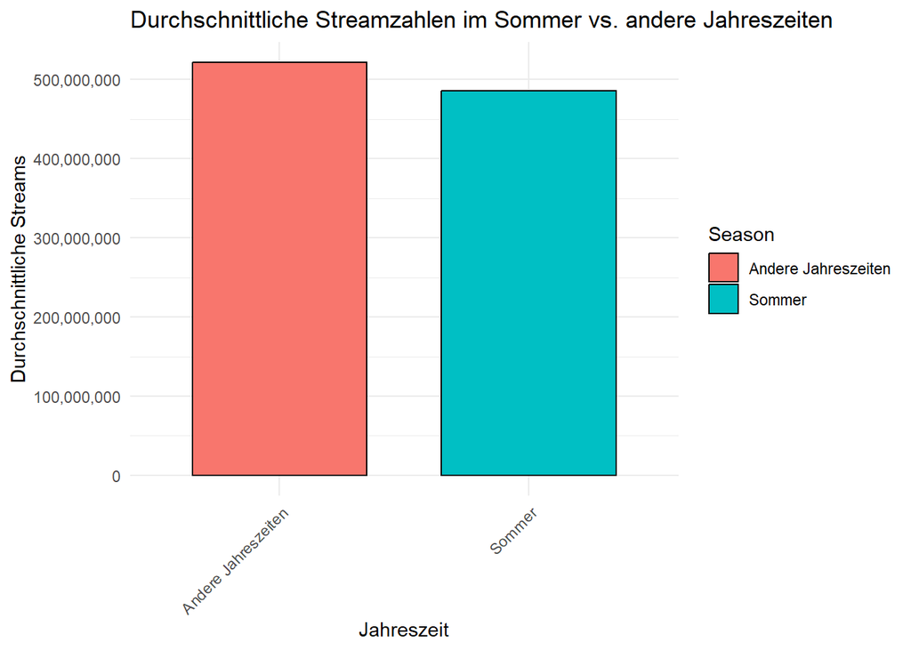

```r
ggplot(bar_data, aes(x = Season, y = Mean_Streams, fill = Season)) +
  geom_bar(stat = "identity", position = "dodge", width = 0.7, color = "black") +
  labs(title = "Durchschnittliche Streamzahlen im Sommer vs. andere Jahreszeiten",
       x = "Jahreszeit",
       y = "Durchschnittliche Streams") +
  theme_minimal()+
  theme(axis.text.x = element_text(angle = 45, hjust = 1)) +
  scale_y_continuous(labels = scales::comma)
```

Zunächst werden hier die durschschnittliche Streams über die verschiedenen Monate berechnet.

```r
mean_streams_january <- mean(dataset$streams[dataset$released_month %in% c(1)])
mean_streams_february <- mean(dataset$streams[dataset$released_month %in% c(2)])
mean_streams_march <- mean(dataset$streams[dataset$released_month %in% c(3)])
mean_streams_april <- mean(dataset$streams[dataset$released_month %in% c(4)])
mean_streams_may <- mean(dataset$streams[dataset$released_month %in% c(5)])
mean_streams_june <- mean(dataset$streams[dataset$released_month %in% c(6)])
mean_streams_july <- mean(dataset$streams[dataset$released_month %in% c(7)])
mean_streams_august <- mean(dataset$streams[dataset$released_month %in% c(8)])
mean_streams_september <- mean(dataset$streams[dataset$released_month %in% c(9)])
mean_streams_october <- mean(dataset$streams[dataset$released_month %in% c(10)])
mean_streams_november <- mean(dataset$streams[dataset$released_month %in% c(11)])
mean_streams_dezember <- mean(dataset$streams[dataset$released_month %in% c(12)])
```

Da diese Werte sind wie oben auch sehr groß um die Werte besser vergleichen zu können und die Aussage interpretieren zu können, werden diese in einem Balkendiagramm dargestellt.

Auch hier werden zunäscht wie der die Daten für das Balkendiagramm vorbereitet.

```r
bar_data_months <- data.frame(
  Month = c("January", "February", "March", "April", "May", "June", "July", "August", "September", "October", "November", "Dezember"),
  Mean_Streams = c(mean_streams_january, mean_streams_february, mean_streams_march, mean_streams_april, mean_streams_may, mean_streams_june, mean_streams_july, mean_streams_august, mean_streams_september, mean_streams_october, mean_streams_november, mean_streams_dezember)
)
```

Die Daten werden vor der Erstellung des Balkendiagramms noch chronologisch sortiert, damit sie den Jahresablauf von links nach recht auf der x-Achse darstellen.

```r
bar_data_months$Month <- factor(bar_data_months$Month, levels = c("January", "February", "March", "April", "May", "June", "July", "August", "September", "October", "November", "Dezember"))
```

Danach wird das Balkendiagramm für die durschnittliche Streamzahlen über die verschiedenen Monate erstellt.-

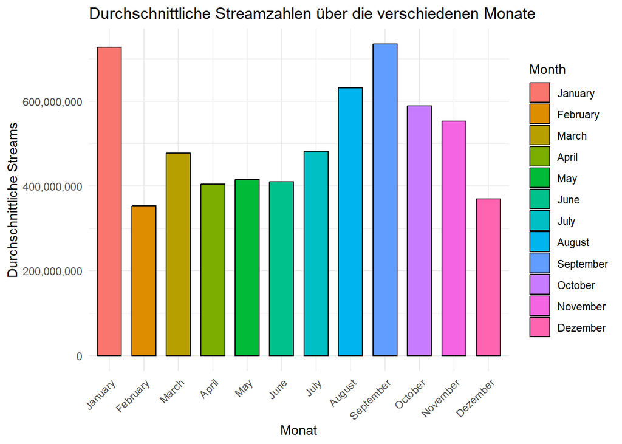

```r
ggplot(bar_data_months, aes(x = Month, y = Mean_Streams, fill = Month)) +
  geom_bar(stat = "identity", position = "dodge", width = 0.7, color = "black") +
  labs(title = "Durchschnittliche Streamzahlen über die verschiedenen Monate",
       x = "Monat",
       y = "Durchschnittliche Streams") +
  theme_minimal() +
  theme(axis.text.x = element_text(angle = 45, hjust = 1)) +
  scale_y_continuous(labels = scales::comma)
```

An den durchschnittlichen Streamzahlen über die verschiedenen Monate lässt sich erkenne, dass die Sommermonate, Verhältnismäßig zu den anderen Monaten, nicht die höchsten Streamzahlen haben. Die Monate aber auch keine Ausreißer sind und relativ nah beieinander sind.

Die höchsten Streamzahlen haben die Monate September, Januar und August. Generell lässt sich erkennen, dass die Streams ab Juli ansteigen und nach dem September bis zum Dezember wieder abfallen. Das könnte darauf zurückzuführen sein, dass die Songs die in den Herbstmonaten veröffentlichen veröffentlichen in der dunkleren Jahreszeit ein Gefühl von Wärme und Geborgenheit geben, nach welchem sich Menschen dann das ganze Jahr über sehnen und diese Songs aus diesem Grund ganzjährig beliebt sind.

Abschließend lässt sich sagen, dass sich die Veröffentlichung im Sommer im Vergleich zu anderen Jahreszeiten nicht zu höheren Streamzahlen führt.

## 6.2 These 2: Je beliebter ein Song ist, desto besser lässt sich zu ihm Tanzen (Tim)

Die These stellt die Vermutung auf, dass sich ein song besser zum tanzen eignet, wenn er beliebt ist. Die These wurde vor dem Hintergrund aufgestellt, dass Songs die in Diskotheken gespielt werden, meistens sehr beliebt sind und sich auch gut zum Tanzen eignen. Um diese These zu überprüfen, wird im folgenden ein Scatterplot erstellt, der die Beliebtheit eines Songs mit der Tanzbarkeit des Songs vergleicht.

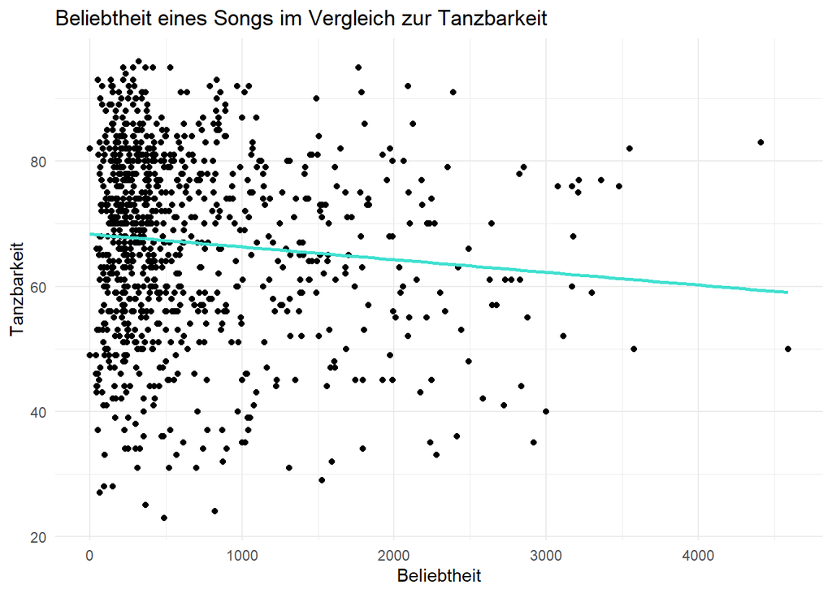

```r
ggplot(dataset, aes(x = popularity_score, y = danceability_percent)) +
  geom_point() +
  geom_smooth(method = "lm", se = FALSE, color = "turquoise") +
  labs(title = "Beliebtheit eines Songs im Vergleich zur Tanzbarkeit",
       x = "Beliebtheit",
       y = "Tanzbarkeit") +
  theme_minimal() +
  scale_y_continuous(labels = scales::comma)
```

Aus dem Scatterplot lässt sich kein Zusammenhang zwischen der Beliebtheit eines Songs und der Tanzbarkeit des Songs erkennen und auch die eingezeichnete Regressionsgerade zeigt keinen Zusammenhang zwischen den beiden Werten an. Um dies zu bestätigen, wird im folgenden der Korrelationskoeffizient berechnet.

```r
cor(dataset$popularity_score, dataset$danceability_percent)
```

```
[1] -0.09577936
```

Aus der linearen Regression lässt sich kein Zusammenhang zwischen den beiden Werten erkennen. Dies wird auch durch den Korrelationskoeffizienten bestätigt, der nahe 0 ist und *-0.0957794* beträgt. Die These kann somit nicht bestätigt werden und die Beliebtheit eines Songs hat keinen Einfluss auf die Tanzbarkeit des Songs.

Zusammenfassend lässt sich sagen, dass die These nicht bestätigt werden kann und die Beliebtheit eines Songs keinen Einfluss auf die Tanzbarkeit des Songs hat und dass keine Korrelation zwischen den beiden Werten besteht.

# 7 Machine Learning Modelle

## 7.1 Machine Learning Modell 1: Regression (Tim)

In diesem Machine Learning Modell wird versucht die Beliebheit eines Songs anhand der Parameter Tanzbarkeit, Energie, Sprachanteil, Akustik, Instrumentalität, Lebendigkeit und Valenz vorherzusagen.

Zunächst werden die Daten standardisiert.

```r
relevant_cols <- c("danceability_percent", "energy_percent", "speechiness_percent", "acousticness_percent", "instrumentalness_percent", "liveness_percent", "valence_percent")
cols_to_scale <- colnames(dataset |>  dplyr::select(all_of(relevant_cols)))
dataset_scale <- dataset |> mutate_at(cols_to_scale, ~(scale(.) |>  as.vector()))
```

Nun werden die Daten in den Trainings- und Testdatensatz aufgeteilt. Um danach eine Valiedirung des Modells auf Basis des Testdatensatzes durchzuführen.

```r
set.seed(1)
dataset_split <- initial_split(dataset_scale, prop = 0.8, strata = popularity_score)
dataset_train <- training(dataset_split)
dataset_test  <- testing(dataset_split)
```

Als nächstes werden sowohl der Testdatensatz als auch der Trainingsdatensatz auf die relevanten Spalten reduziert.

```r
dataset_train <- dataset_train |> select(popularity_score, relevant_cols)
dataset_test <- dataset_test |> select(popularity_score, relevant_cols)
```

Dann wir das Modell initialisiert.

```r
mlp_dataset_mod <-
    mlp() |>
    set_mode("regression") |>
    set_engine("nnet")
```

Und danach wird das Modell trainiert.

```r
set.seed(1)
  mlp_dataset_fit <- mlp_dataset_mod |>
    fit(popularity_score ~ ., data = dataset_train)

mlp_dataset_fit
```

```
parsnip model object

a 7-5-1 network with 46 weights
inputs: danceability_percent energy_percent speechiness_percent acousticness_percent instrumentalness_percent liveness_percent valence_percent
output(s): popularity_score
options were - linear output units
```

Nach dem Training wird das Modell nun auf den Testdatensatzangewendet.

```r
pred <- predict(mlp_dataset_fit, dataset_test)
results <- dataset_test |>  dplyr::select(popularity_score) |> bind_cols(pred)
```

Jetzt wird die Genauigkeit des Modells anhand der Root Mean Squared Error (RMSE) berechnet.

```r
rmse(data = results, truth = popularity_score, estimate = .pred)
```

```
# A tibble: 1 × 3
  .metric .estimator .estimate
  <chr>   <chr>          <dbl>
1 rmse    standard        799.
```

Der RMSE beträgt *rmse, standard, 798.9542875* und ist somit relativ hoch. Dies bedeutet, dass das Modell die Beliebtheit eines Songs nicht gut vorhersagen kann. Dies kann auch anhand des Scatterplots dargestellt werden, der die vorhergesagten Werte mit den tatsächlichen Werten vergleicht.

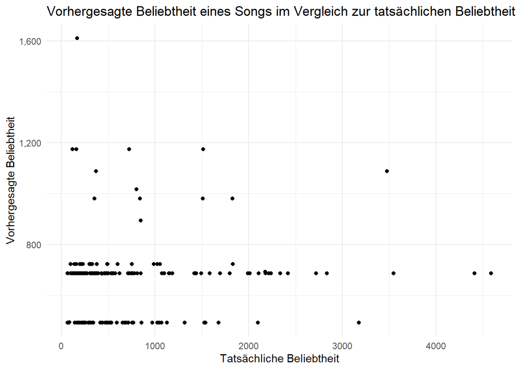

```r
ggplot(results, aes(x = popularity_score, y = .pred)) +
  geom_point() +
  labs(title = "Vorhergesagte Beliebtheit eines Songs im Vergleich zur tatsächlichen Beliebtheit",
       x = "Tatsächliche Beliebtheit",
       y = "Vorhergesagte Beliebtheit") +
  theme_minimal() +
  scale_y_continuous(labels = scales::comma)
```

Dieser Plot zeigt sehr deutlich, dass die eigentlichen Werte und die vorhergesagten Werte sehr stark voneinander abweichen. Dies bestätigt die Aussage, dass das Modell die Beliebtheit eines Songs nicht gut vorhersagen kann. Außerdem lassen sich zwei “Linien” die parallel zur x-Achse verlaufen erkennen. Diese deuten darauf hin, dass das Modell die Beliebtheit eines Songs auf wenige Werte beschränkt und sich in diesen “Linien” widerspiegelt.

Eine Möglichkeit die Genauigkeit des Modells zu verbessern, ist die Anpassung der Hyperparameter. Hierbei wird die Anzahl der versteckten Einheiten von 5 auf 100 erhöht.

Hier wird das Modell auch wieder initialisiert.

```r
mlp_dataset_mod2 <-
    mlp(
      hidden_units = 100
    ) |>
    set_mode("regression") |>
    set_engine("nnet")
```

Dann wird das Modell trainiert.

```r
set.seed(1)
  mlp_dataset_fit2 <- mlp_dataset_mod2 |>
    fit(popularity_score ~ ., data = dataset_train)

mlp_dataset_fit2
```

```
parsnip model object

a 7-100-1 network with 901 weights
inputs: danceability_percent energy_percent speechiness_percent acousticness_percent instrumentalness_percent liveness_percent valence_percent
output(s): popularity_score
options were - linear output units
```

Und es wird wieder versucht eine Vorhersage auf Basis der Testdaten zu treffen.

```r
pred <- predict(mlp_dataset_fit2, dataset_test)
results <- dataset_test |>  dplyr::select(popularity_score) |> bind_cols(pred)
```

Nun wird wie oben der RMSE zur Bestimmung der Genauigkeit herangezogen.

```r
rmse(data = results, truth = popularity_score, estimate = .pred)
```

```
# A tibble: 1 × 3
  .metric .estimator .estimate
  <chr>   <chr>          <dbl>
1 rmse    standard        945.
```

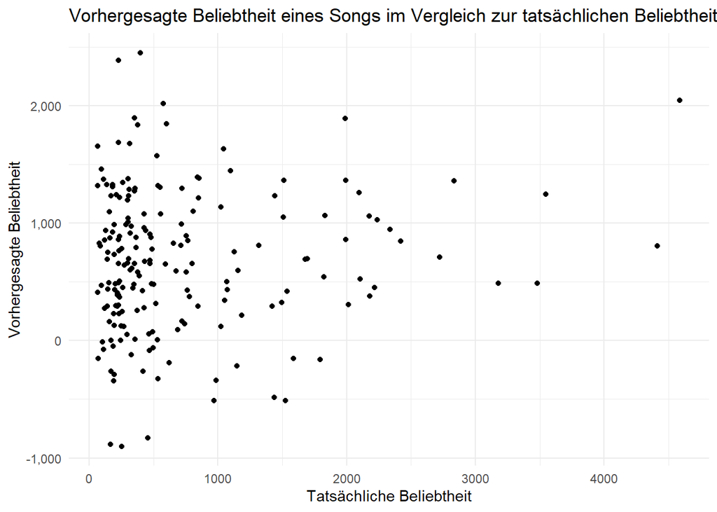

```r
ggplot(results, aes(x = popularity_score, y = .pred)) +
  geom_point() +
  labs(title = "Vorhergesagte Beliebtheit eines Songs im Vergleich zur tatsächlichen Beliebtheit",
       x = "Tatsächliche Beliebtheit",
       y = "Vorhergesagte Beliebtheit") +
  theme_minimal() +
  scale_y_continuous(labels = scales::comma)
```

Dieser Plot zeigt sehr deutlich, dass die eigentlichen Werte und die vorhergesagten Werte sehr stark voneinander abweichen. Teilweise werde sogar Werte im negativen Bereich vorhergesagt. Posistiv ist jedoch, dass sich nicht mehr so deutlich “Linien” in der Darstellung erkennen lassen. Dies bedeutet, dass das Modell die Beliebtheit eines Songs nicht mehr so stark auf wenige Werte beschränkt. Dennoch lassen sich einige vage “Linien” erkennen, wie z.B. um den vorhergesagten Wert 500.

Abschließend lässt sich damit sagen, dass sich der Beliebtheitsscore nicht gut auf Basis der Tanzbarkeit, Energie, Sprachanteil, Akustik, Instrumentalität, Lebendigkeit und Valenz vorhersagen lässt. Auch die Erhöhung der Hidden Layers hat keine Verbesserung in der Genauigkeit gebracht.

# 8 Grenzen des Projekts (Markus)

# 9 Ausblick (Markus)

# 10 Aufgabenverteilung

Tim:  
- Kapitel 5, Berechnung des Beliebtheitsscores  
- Kapitel 4, Bereinigung der Daten  
- Kapitel 6.1, These 1  
- Kapitel 6.2, These 2  
- Kapitel 7.1, ML-Modell 1

Alle nicht genannten Kapitel wurden gemeinsam bearbeitet.

# 11 Quellenverzeichnis

Datensatz:  
- Kaggle (2023): https://www.kaggle.com/datasets/nelgiriyewithana/top-spotify-songs-2023 (Zugriff: 23.12.2023)

Kapitel 5:  
- Statista (13.02.2020): https://www.statista.com/chart/20826/music-streaming-services-with-most-subscribers-global-fipp/ (Zugriff: 23.12.2023)

Verwendetes Theme:  
- Bootswatch (2023): https://bootswatch.com/lux/ (Zugriff: 23.12.2023)

# 12 Ehrenwörtliche Erklärung

Hiermit erklären wir, dass wir die vorliegende Studienarbeit selbständig angefertigt haben. Es wurden nur die in der Arbeit ausdrücklich benannten Quellen und Hilfsmittel benutzt. Wörtlich oder sinngemäß übernommenes Gedankengut haben wir als solches kenntlich gemacht. Diese Arbeit hat in gleicher oder ähnlicher Form ganz oder teilweise noch keiner Prüfungsbehörde vorgelegen.

[figure not shown]

Markus Janke

Bielefed, 23.12.2023

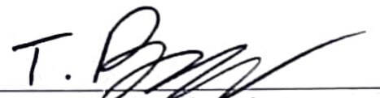

Tim Beyer